# Sesión 2

José Manuel Toral Cruz

March 9, 2018

**NOTA:** Tomen nota de las buenas prácticas en los documentos de Markdown.

# Preliminares

Aquí pondremos todos los paquetes que usaremos.

```r
library(tidyverse)
library(readr)
library(ggmap)
```

# Terrorismo en Pakistán

En esta sesión vamos a trabajar directamente con una bases de datos, vamos a explorarlas y manipularlas. Como ejemplo vamos a usar la base de datos que viene en la carpeta en la página del curso. Esta base se llama “Pakistan Suicide Bombing Attacks: Most Authentic Count of Suicide Bombing Attacks in Pakistan (1995-2016)”. Pese a que el tema no es nada agradable, esta es una de las bases del concurso Kaggel. Mientras jugamos con ella, científicxs de todo el mundo buscan encontrar un modelo que permita predecir el próximo ataque terrorista usando estos datos. Nosotrxs seremos menos aventurados. Igual va a estar cool.

1. Carguemos la base. Esto le causó algunos problemas a varixs la sesión pasada.

```r
pt <- read.csv("/home/manuel/Documents/MCCI/Curso_R/Sesión 2/pakistan_terror.csv",
               stringsAsFactors=FALSE, fileEncoding="latin1")
```

2. Veamos la **estructura** y la **clase** son los datos y si nos conviene tenerlos así.

```r
str(pt)
```

```
## 'data.frame':    496 obs. of  26 variables:
##  $ S.                     : int  1 2 3 4 5 6 7 8 9 10 ...
##  $ Date                   : chr  "Sunday-November 19-1995" "Monday-November 6-2000" "Wednesday-May 8-2002" "Friday-June 14-2002" ...
##  $ Islamic.Date           : chr  "25 Jumaada al-THaany 1416 A.H" "10 SHa`baan 1421 A.H" "25 safar 1423 A.H" "3 Raby` al-THaany 1423 A.H" ...
##  $ Blast.Day.Type         : chr  "Holiday" "Working Day" "Working Day" "Working Day" ...
##  $ Holiday.Type           : chr  "Weekend" "" "" "" ...
##  $ Time                   : chr  "N/A" "N/A" "7:45 AM" "11:10:00 AM" ...
##  $ City                   : chr  "Islamabad" "Karachi" "Karachi " "Karachi" ...
##  $ Latitude               : num  33.7 25 25 25 30.2 ...
##  $ Longitude              : chr  "73.0718" "66.9911" "66.9911" "66.9911" ...
##  $ Province               : chr  "Capital" "Sindh" "Sindh" "Sindh" ...
##  $ Location               : chr  "Egyptian Embassy" "office of Nawa-e-Waqt" "Pakistan Navy bus Parked outside Five Star Sheraton Hotel " "US Consulate Civil Lines Area " ...
##  $ Location.Category      : chr  "Foreign" "Office Building" "Hotel" "Foreign" ...
##  $ Location.Sensitivity   : chr  "High" "Low" "Medium" "High" ...
##  $ Open.Closed.Space      : chr  "Closed" "Closed" "Closed" "Closed" ...
##  $ Influencing.Event.Event: chr  "" "" "" "" ...
##  $ Target.Type            : chr  "Foreigner" "Media" "Foreigner" "Foreigner" ...
##  $ Targeted.Sect.if.any   : chr  "None" "None" "Christian" "Christian" ...
##  $ Killed.Min             : int  14 NA 13 NA 44 16 NA 14 16 NA ...
##  $ Killed.Max             : int  15 3 15 12 47 18 1 15 18 2 ...
##  $ Injured.Min            : int  NA NA 20 NA NA NA 3 96 NA NA ...
##  $ Injured.Max            : chr  "60" "3" "40" "51" ...
##  $ No..of.Suicide.Blasts  : chr  "2" "1" "1" "1" ...
##  $ Explosive.Weight..max. : chr  "" "" "2.5 Kg" NA ...
##  $ Hospital.Names         : chr  "" "" "1.Jinnah Postgraduate Medical Center 2. Civil Hospital Karachi 3. PN Shifa" NA ...
##  $ Temperature.C.         : num  15.8 23.8 31.5 31.4 33.1 ...
##  $ Temperature.F.         : num  60.5 74.8 88.6 88.6 91.6 ...
```

```r
sapply(pt, class)
```

```
##                      S.                    Date            Islamic.Date
##               "integer"             "character"             "character"
##          Blast.Day.Type            Holiday.Type                    Time
##             "character"             "character"             "character"
##                    City                Latitude               Longitude
##             "character"               "numeric"             "character"
##                Province                Location       Location.Category
##             "character"             "character"             "character"
##    Location.Sensitivity       Open.Closed.Space Influencing.Event.Event
##             "character"             "character"             "character"
##             Target.Type    Targeted.Sect.if.any              Killed.Min
##             "character"             "character"               "integer"
##              Killed.Max             Injured.Min             Injured.Max
##               "integer"               "integer"             "character"
##   No..of.Suicide.Blasts  Explosive.Weight..max.          Hospital.Names
##             "character"             "character"             "character"
##          Temperature.C.          Temperature.F.
##               "numeric"               "numeric"
```

# Change class

```r
pt$Longitude <- as.numeric(pt$Longitude)
```

# Recodificar

**Note:** Esto es un excelente recurso para recodificaciones: http://rprogramming.net/recode-data-in-r/

```r
unique(pt$Location.Sensitivity)
```

```
## [1] "High"   "Low"    "Medium" ""       "low"
```

```r
unique(pt$Location.Sensitivity)[4]
```

```
## [1] ""
```

```r
pt$Location.Sensitivity[pt$Location.Sensitivity=="low"] <- "Low"
pt$Location.Sensitivity[pt$Location.Sensitivity==""] <- NA

pt$Location.Sensitivity <- as.factor(pt$Location.Sensitivity)
levels(pt$Location.Sensitivity)
```

```
## [1] "High"   "Low"    "Medium"
```

# Una gráfica

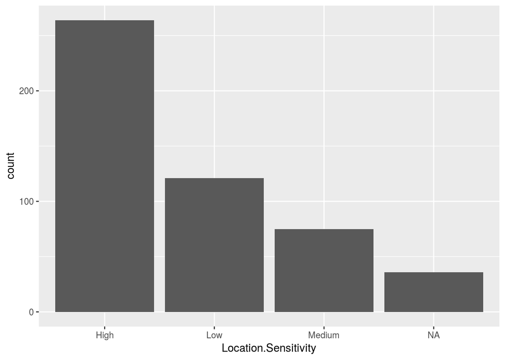

```r
bar1 <- ggplot(pt, aes(Location.Sensitivity)) +
  geom_bar()

bar1
```

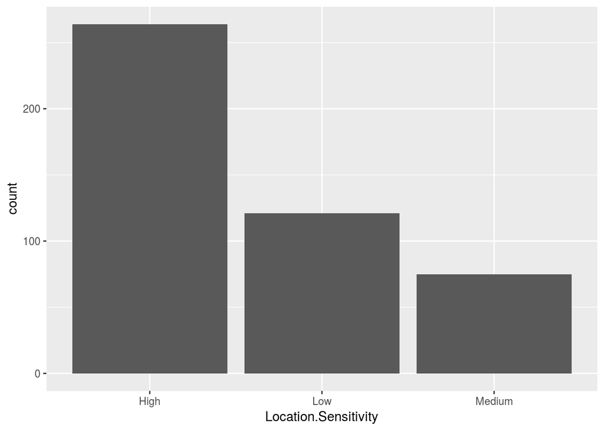

```r
bar2 <-  ggplot(subset(pt, !is.na(pt$Location.Sensitivity)), aes(Location.Sensitivity)) + geom_bar()

bar2
```

Ya sé, están medio feas.

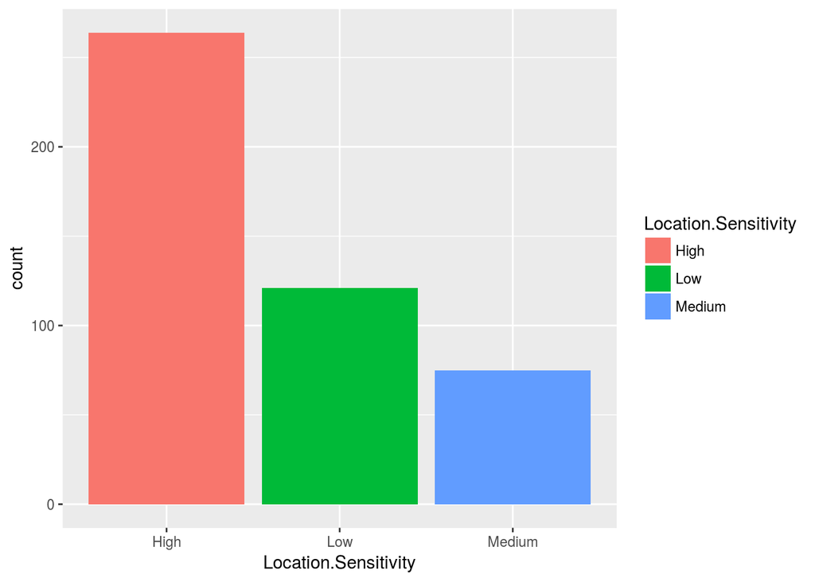

```r
bar2 <-  ggplot(subset(pt, !is.na(pt$Location.Sensitivity)),
                aes(Location.Sensitivity, fill=Location.Sensitivity)) +
  geom_bar()

bar2
```

Por si les sigue sin gustar…

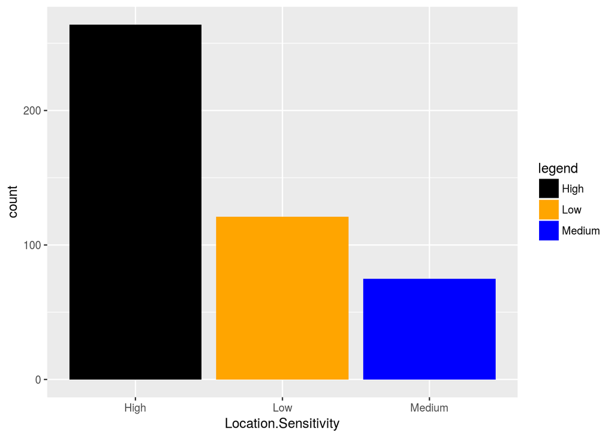

```r
bar2 <-  ggplot(subset(pt, !is.na(pt$Location.Sensitivity)),
                aes(Location.Sensitivity, fill=Location.Sensitivity)) +
  geom_bar() +
  scale_fill_manual("legend", values = c("High" = "black", "Low" = "orange", "Medium" = "blue"))

bar2
```